# MAD – Data Analysis & Biostatistics in R

23 October 2020

[figure not shown]

## Introduction

## R Does Biology?

- R has many resources for biology
  - In *Base R*, `seqinr`, `ape`, `bioseq` and many others
  - In *Bioconductor*,
    - Many advanced algorithms
    - Manipulation of genomic sequences
    - Manipulation of gene expression data
    - Data files of various organisms
  - Other platforms as well

## Bioconductor

## Bioconductor Conception

[figure not shown]

- Project initiated in 2001
- 1,903 software packages
  - Software
  - Annotation
  - Experiment
- Uses S4 object-oriented subsystem in R
  - More complicated than normal base R
  - Stricter logic than S3 (i.e., base R)
- Powerful algorithms

## Install Bioconductor

- Site: https://www.bioconductor.org/
- Install base modules in R
  - With most recent version of R (4.0.3) installed
  - After 27/10, Bioconductor version number will be 3.12

  ```r
  if (!requireNamespace("BiocManager", quietly = TRUE))
      install.packages("BiocManager")
  BiocManager::install(version = "3.11")
  ```

- With `BiocManager` installed, install Bioconductor packages with:
  - `BiocManager::install("packagename")`

## Different Types of Analyses Available in Bioconductor

- Sequencing : RNASeq, ChIPSeq, variants, copy number,…
- Microarrays: expression, SNP,…
- Domain specific analysis : Flow cytometry, Proteomics,…

## Variety of File Types Supported

- fasta, fastq
- BAM, gtf, bed, wig
- Nexus, Newick (tree formats)

## Example of Bioconductor Power

- Study that I worked on about bacteriophages
- This example takes a set of DNA sequences, aligns them, and finds a consensus
- Main alignment functions are in `msa` (“multiple sequence alignment”) package

## Load Data and Packages

- `tail_dna` a **DNAStringSet** object
  - Set of DNA strings in BioConductor `Biostrings` format
  - Created directly with `DNAStringSet()` function from fasta file

```r
library(msa)
library(tidyverse)
tail_dna <- readRDS(here::here("grt20pct_dna.rds"))
```

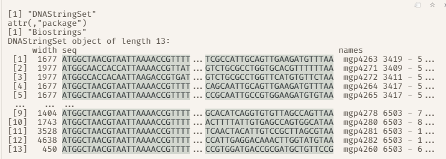

## Perform the alignment using `msa` package

- Uses ClustalW algorithm

```r
tail_align <- msa(tail_dna)
```

```
## use default substitution matrix
```

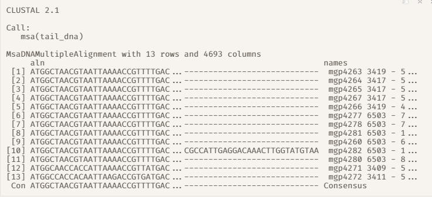

## Develop and Show Consensus

```r
consensus <- msaConsensusSequence(tail_align)
mini_consensus <- str_sub(consensus, 1, 1712)
```

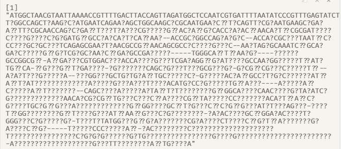

## Comments on Bioconductor

- Very powerful but needs a lot of attention
- Printing of results requires a lot of work

## `bioseq`

## New Package in CRAN

- Uploaded to CRAN July 2020
- Uses normal S3 programming logic
- Basic operations: can do much what of Bioconductor can do
  - Except alignment - still need `msa` or outside resource
- Much easier syntax than predecessor `seqinr`
- Treats DNA, RNA and AA strings as R string vectors
  - Can be manipulated by normal string functions from `stringr`
- Plays well with the tidyverse

## Read File

```r
pac_dna <- read_fasta(here("pac2_56_nucs.fasta"))
class(pac_dna)
```

```
## [1] "bioseq_dna" "vctrs_vctr"
```

```r
pac_dna
```

```
## DNA vector of 3 sequences
## pre_2_A  CCTCAAATCACTCTTTGGCAACGACCCCTCGTCACAATAAAGATAGGGGGGCAAC
## pre_2_B  CCTCAAATCACTCTTTGGCAACGACCCCTCGTCACAGTAAAGATAGGGGGGCAAC
## NC001    GGTCTCTCTGGTTAGACCAGATCTGAGCCTGGGAGCTCTCTGGCTAACTAGGGAA
```

## btw, In Color on Your Screen

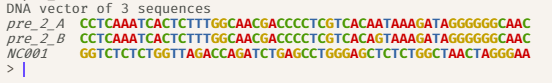

## Difference from Regular R Strings

- `bioseq` string has restricted alphabet
- IUPAC symbols for DNA nucleotides
  - 4 principal: A, C, G, T
  - Other for options: W, S, M, K, R, Y, B, D, H, V, N, -

## Function `dna()` Informs if Bad Characters

- Good at picking up your mistakes in typing
  - Converts bad characters to “N”
- Also converts all characters to upper case

```r
bad_string <- "!3CxDa"
dna(bad_string)
```

```
## DNA vector of 1 sequences
## >   NNCNDA
```

## `bioseq` and the Central Dogma

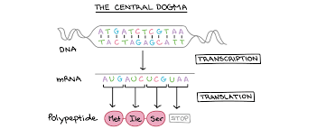

Source: Khan Academy

## Transcription in `bioseq`

- `seq_transcribe()` modifies string to RNA
  - Exchanges *Thymine* for *Uracil*

```r
pac_rna <- seq_transcribe(pac_dna)
pac_rna
```

```
## RNA vector of 3 sequences
## >   CCUCAAAUCACUCUUUGGCAACGACCCCUCGUCACAAUAAAGAUAGGGGGGCAAC
## >   CCUCAAAUCACUCUUUGGCAACGACCCCUCGUCACAGUAAAGAUAGGGGGGCAAC
## >   GGUCUCUCUGGUUAGACCAGAUCUGAGCCUGGGAGCUCUCUGGCUAACUAGGGAA
```

## Translation in `bioseq`

- `seq_translate()` converts the transcribed mRNA to amino acids
- Assumes the reading frame starts at the first nucleotide

```r
pac_aa <- seq_translate(pac_rna)
pac_aa
```

```
## AA vector of 3 sequences
## >   PQITLWQRPLVTIKIGGQ
## >   PQITLWQRPLVTVKIGGQ
## >   GLSG*TRSEPGSSLAN*G
```

## Reverse Transcription and Translation Also Possible

- `seq_rev_transcribe(pac_rna[1])`
  - CCTCAAATCACTCTTTGGCAACGACCCCTCGTCACAATAAAGATAGGGGGGCAAC
- `seq_rev_translate(pac_aa[1])`
  - Not really useful
  - Multiple codons translating to a given AA
  - Ambiguous characters

## Complements and Reverse Complements

- First, do complement with `seq_complement()`
- Then reverse it with `seq_reverse()`

```r
pac_dna[3]
```

```
## DNA vector of 1 sequences
## NC001  GGTCTCTCTGGTTAGACCAGATCTGAGCCTGGGAGCTCTCTGGCTAACTAGGGAA
```

```r
(pac_dna_comp <- seq_complement(pac_dna[3]))
```

```
## DNA vector of 1 sequences
## NC001  CCAGAGAGACCAATCTGGTCTAGACTCGGACCCTCGAGAGACCGATTGATCCCTT
```

```r
(pac_dna_revcomp <- seq_reverse(pac_dna_comp))
```

```
## DNA vector of 1 sequences
## NC001  TTCCCTAGTTAGCCAGAGAGCTCCCAGGCTCAGATCTGGTCTAACCAGAGAGACC
```

## Normal String Functions with `bioseq`

- Sequence is just a normal character vector
  - Can be manipulated with `stringr` functions
- Special string functions (aware of limited alphabet)
  - `seq_detect_pattern()` - find a specific set of letters in a sequence
    - `bioseq` internally disambiguates ambiguous characters
  - `seq_remove_pattern()` - find and remove a substring
  - `seq_replace_pattern()` - substitute one substring for another
  - `seq_disambiguate_IUPAC()` - show all alternatives for ambiguous IUPAC characters

## Useful IUPAC Codes

```
## # A tibble: 10 x 2
##    IUPAC    Base
##    <chr>    <chr>
##  1 A        Adenine
##  2 C        Cytosine
##  3 G        Guanine
##  4 T (or U) Thymine (or Uracil)
##  5 R        A or G
##  6 Y        C or T
##  7 S        G or C
##  8 W        A or T
##  9 K        G or T
## 10 M        A or C
```

## Example of Sequence Character Functions

```r
pac_dna
```

```
## DNA vector of 3 sequences
## pre_2_A  CCTCAAATCACTCTTTGGCAACGACCCCTCGTCACAATAAAGATAGGGGGGCAAC
## pre_2_B  CCTCAAATCACTCTTTGGCAACGACCCCTCGTCACAGTAAAGATAGGGGGGCAAC
## NC001    GGTCTCTCTGGTTAGACCAGATCTGAGCCTGGGAGCTCTCTGGCTAACTAGGGAA
```

```r
seq_detect_pattern(pac_dna, dna("GGGG"))
```

```
## [1]  TRUE  TRUE FALSE
```

```r
seq_detect_pattern(pac_dna, dna("RRGG"))
```

```
## [1] TRUE TRUE TRUE
```

## Example - 2

```r
(sample <- dna("AATCGCCRGTAAAAW"))
```

```
## DNA vector of 1 sequences
## >   AATCGCCRGTAAAAW
```

```r
seq_remove_pattern(sample, dna("TA"))
```

```
## DNA vector of 1 sequences
## >   AATCGCCRGAAAW
```

## Example - 3

```r
seq_replace_pattern(sample,
                    pattern = dna("TA"),
                    replacement = dna("--"))
```

```
## DNA vector of 1 sequences
## >   AATCGCCRG--AAAW
```

```r
seq_disambiguate_IUPAC(dna("CRGT"))
```

```
## [[1]]
## DNA vector of 2 sequences
## >   CAGT
## >   CGGT
```

## Returning to Nucleotide and AA Names from Letters

- Useful little function
- Even converts ambiguous nucleotides

```r
x <- dna("CRGTAW")
seq_spellout(x)
```

```
## [1] "cytosine - purine - guanine - thymine - adenine - weak"
```

```r
aa <- aa("pqitl")
seq_spellout(aa)
```

```
## [1] "proline - glutamine - isoleucine - threonine - leucine"
```

## `bioseq` to Prepare a Set of Sequences for a Phylogenetic Tree

## Setup

- Taken from `bioseq` vignette
- Subject: *Fragilaria* diatoms
  - Major group of microscopic aquatic algae
  - Differentiating according to the RbcL gene
    - Gene responsible for conversion of \(CO_2\) and water into carbohydrates in plants
  - Data comes from NCBI

## Load *fragilia* Data

```r
(fra_data <- read_fasta(fragilaria))
```

```
## DNA vector of 41 sequences
## MK576039.1 Fragil...  TTCATCGCTTATGAATGTGATTTATTTGAAGAAGGTTCTTTAGCTAACTTAACAGCTTCT... + 575 bases
## MK672908.1 Fragil...  GCTTTCATCGCTTACGAATGTGATTTATTTGAAGAAGGTTCTTTAGCTAACTTAACAGCT... + 1107 bases
## MK672907.1 Fragil...  ATGTCTCAATCTGTATCAGAACGGACTCGAATCAAAAGTGACCGTTACGAATCTGGTGTA... + 1386 bases
## MK672906.1 Fragil...  ATGTCTCAATCTGTATCAGAACGGACTCGAATCAAAAGTGACCGTTACGAATCTGGTGTA... + 1386 bases
## KT072939.1 Fragil...  TTAGCATTATTCCGTATTACTCCACAACCAGGTGTAGATCCAGTAGAAGCAGCAGCAGCA... + 744 bases
## KT072928.1 Fragil...  TTAGCATTATTCCGTATTACTCCACAACCAGGTGTAGATCCAGTAGAAGCAGCAGCAGCA... + 744 bases
## KT072903.1 Fragil...  TTAGCATTATTCCGTATTACTCCACAACCAGGTGTAGATCCAGTAGAAGCAGCAGCAGCA... + 744 bases
## MF092945.1 Fragil...  AGTGACCGTTACGAATCTGGTGTAATCCCTTACGCTAAAATGGGTTACTGGGATGCTTCA... + 1263 bases
## MF092943.1 Fragil...  AGTGACCGTTACGAATCTGGTGTAATCCCTTACGCTAAAATGGGTTACTGGGATGCTTCA... + 1263 bases
## JQ003574.1 Synedr...  AAAAANTATGGGCGTGTAGTATACGAAGGTTTAAAAGGTGGATTAGACTTCTTAAAAGAT... + 390 bases
## JQ003570.1 Fragil...  ATTCCACACTCATACTTAAAAACATTCCAAGGTCCAGCAACTGGTATCATCGTAGAACGT... + 516 bases
## JQ003569.1 Synedr...  AAAAACTACGGTCGTGTAGTATATGAAGGTTTAAAAGGTGGTTTAGACTTCTTAAAAGAT... + 390 bases
## ... with 29 more sequences.
```

## Turn the Data into a Tibble

```r
fra_data_t <- tibble(label = names(fra_data), sequence = fra_data) %>%
  mutate(taxa = str_split_fixed(label, pattern = " ", n = 2)[,2],
         n_base = seq_nchar(sequence))
```

```
## # A tibble: 10 x 3
##    label                             taxa                   n_base
##    <chr>                             <chr>                   <int>
##  1 MK576039.1 Fragilaria MK576039.1  Fragilaria MK576039.1     635
##  2 MK672908.1 Fragilaria joachimii   Fragilaria joachimii     1167
##  3 MK672907.1 Fragilaria heatherae   Fragilaria heatherae     1446
##  4 MK672906.1 Fragilaria agnesiae    Fragilaria agnesiae      1446
##  5 KT072939.1 Fragilaria rumpens     Fragilaria rumpens        804
##  6 KT072928.1 Fragilaria capucina    Fragilaria capucina       804
##  7 KT072903.1 Fragilaria crotonensis Fragilaria crotonensis    804
##  8 MF092945.1 Fragilaria MF092945.1  Fragilaria MF092945.1    1323
##  9 MF092943.1 Fragilaria MF092943.1  Fragilaria MF092943.1    1323
## 10 JQ003574.1 Synedra radians        Synedra radians           450
```

## Crop Sequences to Find Region of Interest

- Region of interest can be delimited by forward and reverse primers
- Crop the sequences using these primers
- Some of primer characters are ambiguous (eg. “W”)
  - `bioseq` will resolve them through `seq_disamgiguate_IUPAC()`
  - 3 sequences become 8

## Setting Primers

```r
FWD <- dna("AGGTGAAGTAAAAGGTTCWTACTTAAA",
           "AGGTGAAGTTAAAGGTTCWTAYTTAAA",
           "AGGTGAAACTAAAGGTTCWTACTTAAA")

REV <- dna("CAGTWGTWGGTAAATTAGAAGG",
           "CTGTTGTWGGTAAATTAGAAGG")
```

## FWD Primer Disambiguation

```r
seq_disambiguate_IUPAC(FWD)
```

```
## [[1]]
## DNA vector of 2 sequences
## >   AGGTGAAGTAAAAGGTTCATACTTAAA
## >   AGGTGAAGTAAAAGGTTCTTACTTAAA
##
## [[2]]
## DNA vector of 4 sequences
## >   AGGTGAAGTTAAAGGTTCATACTTAAA
## >   AGGTGAAGTTAAAGGTTCTTACTTAAA
## >   AGGTGAAGTTAAAGGTTCATATTTAAA
## >   AGGTGAAGTTAAAGGTTCTTATTTAAA
##
## [[3]]
## DNA vector of 2 sequences
## >   AGGTGAAACTAAAGGTTCATACTTAAA
## >   AGGTGAAACTAAAGGTTCTTACTTAAA
```

## Crop Sequences

- `FWD` and `REV` as delimiters of all the sequences
- Creates much more limited sequence to put in tree
- Functions as an informal alignment tool

```r
fra_data_t <- fra_data_t %>%
  mutate(cropped_seq = seq_crop_pattern(sequence,
                                    pattern_in = list(FWD),
                                    pattern_out = list(REV)),
         new_n_base = nchar(cropped_seq))
```

## Result of Cropping

```
## # A tibble: 41 x 3
##    taxa                   cropped_seq          new_n_base
##    <chr>                  <chr>                     <int>
##  1 Fragilaria MK576039.1  <NA>                         NA
##  2 Fragilaria joachimii   CATCACTGCTGCTACTATGG        263
##  3 Fragilaria heatherae   CATCACTGCTGCTACTATGG        263
##  4 Fragilaria agnesiae    CATCACTGCTGCTACTATGG        263
##  5 Fragilaria rumpens     <NA>                         NA
##  6 Fragilaria capucina    <NA>                         NA
##  7 Fragilaria crotonensis <NA>                         NA
##  8 Fragilaria MF092945.1  CATCACAGCTGCTACTATGG        263
##  9 Fragilaria MF092943.1  CATTACTGCTGCTACTATGG        263
## 10 Synedra radians        <NA>                         NA
## # ... with 31 more rows
```

## Eliminate the Sequences that Lack the Target Substring

- Eliminate those taxa that have a `NA` cropped region
  - They are not needed for tree

```r
fra_data_red <- fra_data_t %>%
  filter(!is.na(cropped_seq))
```

## Reduced Data Set

```
## # A tibble: 23 x 3
##    taxa                  cropped_seq          new_n_base
##    <chr>                 <chr>                     <int>
##  1 Fragilaria joachimii  CATCACTGCTGCTACTATGG        263
##  2 Fragilaria heatherae  CATCACTGCTGCTACTATGG        263
##  3 Fragilaria agnesiae   CATCACTGCTGCTACTATGG        263
##  4 Fragilaria MF092945.1 CATCACAGCTGCTACTATGG        263
##  5 Fragilaria MF092943.1 CATTACTGCTGCTACTATGG        263
##  6 Fragilaria EU090046.1 CATCACAGCTGCTACTATGG        263
##  7 Fragilaria EU090045.1 CATCACAGCTGCTACTATGG        263
##  8 Fragilaria EU090044.1 CATCACAGCTGCTACTATGG        263
##  9 Fragilaria EU090043.1 CATCACAGCTGCTACTATGG        263
## 10 Fragilaria EU090042.1 CATCACAGCTGCTACTATGG        263
## # ... with 13 more rows
```

## Select Consensus Sequence for Each Taxa

- For phylogenetic tree, we want one sequence per taxa
  - Use a consensus sequence with `seq_consensus()`
    - Function has multiple methods for choosing
    - Explanations are not very clear
    - Until help improved, use `chr_majority` method

```r
fra_data_con <- fra_data_red %>%
  group_by(taxa) %>%
  summarise(consensus_seq = seq_consensus(cropped_seq),
            .groups = "drop")
```

## Results of Consensus

```
## # A tibble: 10 x 2
##    taxa                   consensus_seq
##    <chr>                  <DNA>
##  1 Fragilaria agnesiae    CATCACTGCTGCTACTATGGAAGAACTTTACAAACGTGGT
##  2 Fragilaria bidens      CATCACTGCTGCTACTATGGAAGAACTTTACAAACGTGGT
##  3 Fragilaria crotonensis CATCACTGCTGCTACTATGGAAGAACTTTACAAACGTGGT
##  4 Fragilaria EU090039.1  CATCACAGCTGCTACTATGGAAGAAGTTTACAAGCGTGGT
##  5 Fragilaria EU090041.1  CATCACAGCTGCTACTATGGAAGAAGTTTACAAGCGTGGT
##  6 Fragilaria EU090042.1  CATCACAGCTGCTACTATGGAAGAAGTTTACAAGCGTGGT
##  7 Fragilaria EU090043.1  CATCACAGCTGCTACTATGGAAGAAGTTTACAAGCGTGGT
##  8 Fragilaria EU090044.1  CATCACAGCTGCTACTATGGAAGAAGTTTACAAGCGTGGT
##  9 Fragilaria EU090045.1  CATCACAGCTGCTACTATGGAAGAAGTTTACAAGCGTGGT
## 10 Fragilaria EU090046.1  CATCACAGCTGCTACTATGGAAGAAGTTTACAAGCGTGGT
```

## Should We Keep Duplicate Taxa?

- Some taxa are identical to others in the region of interest
- Can find this out by using base R function `duplicated()`
- For some cases, you can decide to keep duplicates
- For here, we will use a different approach

```r
duplicated(fra_data_con$consensus_seq)
```

```
##  [1] FALSE FALSE FALSE FALSE FALSE  TRUE  TRUE  TRUE  TRUE  TRUE FALSE FALSE
## [13] FALSE  TRUE FALSE FALSE FALSE FALSE FALSE  TRUE
```

## Clustering Approach

- Instead, we will cluster the consensus sequences based on their similarity
- This uses `bioseq::seq_cluster()`
  - Implements hierarchical clustering method
    - One of principal unsupervised machine learning methods
    - Calculates the multivariate distance between all pairs of sequences
    - Groups these into similar “clusters” of items
      - Which have a minimum (threshold) distance to the neighboring clusters

## Code for Clustering

```r
fra_data_con <- fra_data_con %>%
  mutate(cluster = seq_cluster(consensus_seq,
                               threshold = 0.001))
```

## Clusters

```
## # A tibble: 20 x 3
##    taxa                   consensus_seq        cluster
##    <chr>                  <chr>                  <int>
##  1 Fragilaria agnesiae    CATCACTGCTGCTACTATGG       1
##  2 Fragilaria bidens      CATCACTGCTGCTACTATGG       2
##  3 Fragilaria crotonensis CATCACTGCTGCTACTATGG       3
##  4 Fragilaria EU090039.1  CATCACAGCTGCTACTATGG       4
##  5 Fragilaria EU090041.1  CATCACAGCTGCTACTATGG       5
##  6 Fragilaria EU090042.1  CATCACAGCTGCTACTATGG       5
##  7 Fragilaria EU090043.1  CATCACAGCTGCTACTATGG       5
##  8 Fragilaria EU090044.1  CATCACAGCTGCTACTATGG       5
##  9 Fragilaria EU090045.1  CATCACAGCTGCTACTATGG       5
## 10 Fragilaria EU090046.1  CATCACAGCTGCTACTATGG       5
## 11 Fragilaria famelica    CATCACTGCTGCTACTATGG       6
## 12 Fragilaria heatherae   CATCACTGCTGCTACTATGG       7
## 13 Fragilaria joachimii   CATCACTGCTGCTACTATGG       8
## 14 Fragilaria KC969741.1  CATCACAGCTGCTACTATGG       4
## 15 Fragilaria KC969742.1  CGTTACAGCTGCTACTATGG       9
## 16 Fragilaria MF092943.1  CATTACTGCTGCTACTATGG      10
## 17 Fragilaria MF092945.1  CATCACAGCTGCTACTATGG      11
## 18 Fragilaria perminuta   CATTACTGCTGCTACTATGG      12
## 19 Fragilaria rumpens     CATCACGGCTGCTACTATGG      13
## 20 Fragilaria striatula   CATCACAGCTGCTACTATGG       4
```

## Reconstruct Consensus Sequences Based on Clusters

- A consensus for every cluster

```r
fra_data_con_2 <- fra_data_con %>%
  group_by(cluster) %>%
  summarise(taxa_group = paste(taxa, collapse = "/"),
            consensus_seq = seq_consensus(consensus_seq),
            .groups = "drop")
```

## New Cluster Consensus

```
## # A tibble: 13 x 2
##    cluster taxa_group
##      <int> <chr>
##  1       1 Fragilaria agnesiae
##  2       2 Fragilaria bidens
##  3       3 Fragilaria crotonensis
##  4       4 Fragilaria EU090039.1/Fragilaria KC969741.1/Fragilaria striatula
##  5       5 Fragilaria EU090041.1/Fragilaria EU090042.1/Fragilaria EU090043.1/Fr~
##  6       6 Fragilaria famelica
##  7       7 Fragilaria heatherae
##  8       8 Fragilaria joachimii
##  9       9 Fragilaria KC969742.1
## 10      10 Fragilaria MF092943.1
## 11      11 Fragilaria MF092945.1
## 12      12 Fragilaria perminuta
## 13      13 Fragilaria rumpens
```

## Time to Draw the Tree - 3 Steps

1. Convert consensus sequences to `DNAbin` format
   - bit-level encoding of sequences
   - binary encoding format permits more rapid comparisons of sequences
   - more economic storage
   - `bioseq::as_DNAbin()`
2. Calculate distance matrix among all taxa
   - Call `ape::dist.dna()`
3. Calculate a neighbor-joining tree with `ape::bionj()`

## Code for Tree Calculation

```r
fra_tree <- fra_data_con_2 %>%
  as_DNAbin(consensus_seq, taxa_group) %>%
  ape::dist.dna() %>%
  ape::bionj()
```

## Draw with `plot()`

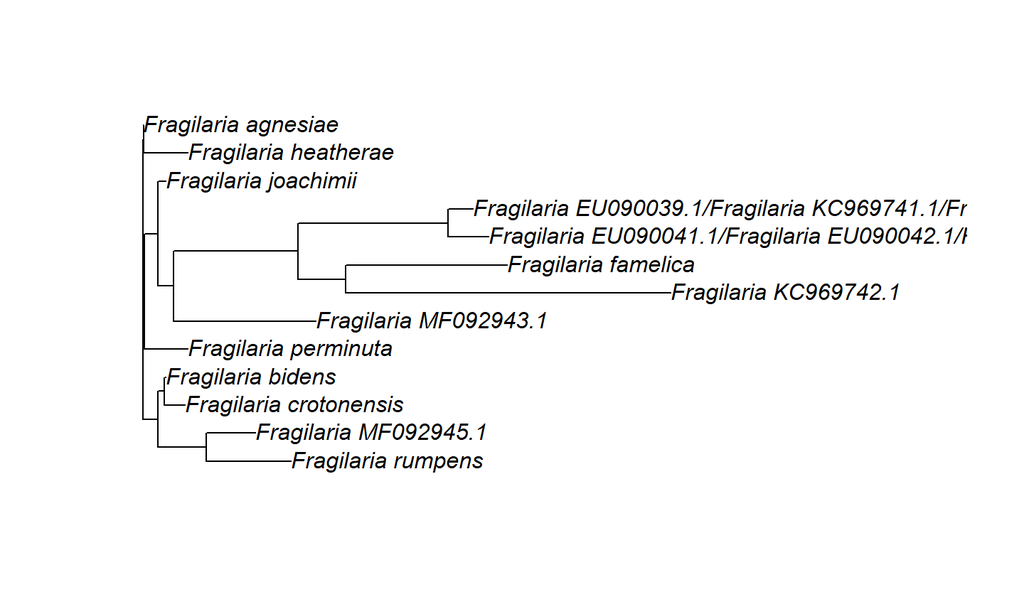

```r
plot(fra_tree)
```

## How to Work with Bioconductor and `bioseq`

## Strategy for Working with Bioconductor Modules

- Since the data preparation is complicated …
- Prepare your sequences, etc. in `bioseq`
- Either read them directly into a Bioconductor function
- Or, write them to a fasta file (`write_fasta()`) and use one of `Biostrings` functions to convert them to Bioconductor format
  - E.g., `DNAStringSet()`

## Second Biomedical Problem

## Nature of Problem

- Testing level of expression of group of bacteriophages in HIV patients
- Desire to produce a heatmap showing relative strength of the phages across the panel of patients
- Work of Rodrigo Sanz, Post-Doc, and Prof. Shirley Komninakis of Retro
- We will focus here on families of phages

## 2 Approaches to Problem

- Front Door: tidy the data, then analyze it
- Other: What does the function that generates heatmaps need?
  - Do that

## The Data in Spreadsheet Form

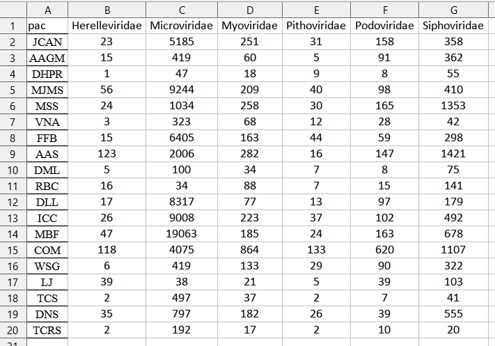

## Read the Data with `read_excel()`

```r
data_fam <- read_excel(here("Planilha Bacteriofagos por familia.xlsx"))
str(data_fam)
```

```
## tibble [19 x 7] (S3: tbl_df/tbl/data.frame)
##  $ pac           : chr [1:19] "JCAN" "AAGM" "DHPR" "MJMS" ...
##  $ Herelleviridae: num [1:19] 23 15 1 56 24 3 15 123 5 16 ...
##  $ Microviridae  : num [1:19] 5185 419 47 9244 1034 ...
##  $ Myoviridae    : num [1:19] 251 60 18 209 258 68 163 282 34 88 ...
##  $ Pithoviridae  : num [1:19] 31 5 9 40 30 12 44 16 7 7 ...
##  $ Podoviridae   : num [1:19] 158 91 8 98 165 28 59 147 8 15 ...
##  $ Siphoviridae  : num [1:19] 358 362 55 410 1353 ...
```

## Are These Data Tidy?

- What do you think?

## Are These Data Tidy?

- NO
- Data unit is the number of hits
- The number of hits belongs to a **family** of phages and to a **patient**
- Case of variables being really instances
- We fix this with `tidyr::pivot_longer()`

## Put the Data in ‘Long’ Format

```r
data_fam_long <- data_fam  %>%
  pivot_longer(cols = 2:7, names_to = "family", values_to = "hits")
str(data_fam_long)
```

```
## tibble [114 x 3] (S3: tbl_df/tbl/data.frame)
##  $ pac   : chr [1:114] "JCAN" "JCAN" "JCAN" "JCAN" ...
##  $ family: chr [1:114] "Herelleviridae" "Microviridae" "Myoviridae" "Pithoviridae" ...
##  $ hits  : num [1:114] 23 5185 251 31 158 ...
```

## Are the Data Balanced Across Families?

- Look at mean of `hits` by `family`

```r
data_fam_long %>%
  group_by(family) %>%
  summarise(mean_hits = mean(hits),
            .groups = "drop")
```

```
## # A tibble: 6 x 2
##   family         mean_hits
##   <chr>              <dbl>
## 1 Herelleviridae      30.2
## 2 Microviridae      3537
## 3 Myoviridae         167.
## 4 Pithoviridae        24.8
## 5 Podoviridae        102.
## 6 Siphoviridae       422.
```

## Way Unbalanced

- Range of 25 to 3537
  - *Microviridae* will deominate heatmap
- We can bring them more into scale by **normalizing** them by family
- Calculate the distance from the mean of the family in units of standard deviations (a Z-score) \[Z=\frac{hits - mean(hits)}{std. dev}\]

## Calculate Normalized Hits

```r
data_fam_norm <- data_fam_long %>%
  group_by(family) %>%
  mutate(norm_hits = (hits - mean(hits))/sd(hits))
```

## Normalized Data

```
## # A tibble: 114 x 4
## # Groups:   family [6]
##    pac   family          hits norm_hits
##    <chr> <chr>          <dbl>     <dbl>
##  1 JCAN  Herelleviridae    23    -0.201
##  2 JCAN  Microviridae    5185     0.329
##  3 JCAN  Myoviridae       251     0.440
##  4 JCAN  Pithoviridae      31     0.209
##  5 JCAN  Podoviridae      158     0.405
##  6 JCAN  Siphoviridae     358    -0.147
##  7 AAGM  Herelleviridae    15    -0.427
##  8 AAGM  Microviridae     419    -0.622
##  9 AAGM  Myoviridae        60    -0.559
## 10 AAGM  Pithoviridae       5    -0.673
## # ... with 104 more rows
```

## Check Normalized Values

- If we did this correctly,
  - Mean of normalized hits per family should be 0
  - Standard deviation should be 1

## Code for Check

```r
x <- data_fam_norm %>%
  group_by(family) %>%
  summarise(mean_hits = round(mean(hits), 2),
            sd_hits = round(sd(hits), 2),
            mean_norm_hits = round(mean(norm_hits),2),
            sd_norm_hits =round(sd(norm_hits),2),
            .groups = "drop")
```

## Check on Normalization

```
## # A tibble: 6 x 5
##   family         mean_hits sd_hits mean_norm_hits sd_norm_hits
##   <chr>              <dbl>   <dbl>          <dbl>        <dbl>
## 1 Herelleviridae      30.2    35.5              0            1
## 2 Microviridae      3537    5014.               0            1
## 3 Myoviridae         167.    191.               0            1
## 4 Pithoviridae        24.8    29.5              0            1
## 5 Podoviridae        102.    137.               0            1
## 6 Siphoviridae       422.    435.               0            1
```

## Boxplot of Normalized Values

```r
gg1 <- data_fam_norm %>%
  group_by(family) %>%
  ggplot(aes(x = family, y = norm_hits)) +
  labs(title = "Normalized Number of Hits per Bacteriophage Family",
       x = "Family",
       y = "Normalized Number of Hits") +
  geom_boxplot(outlier.shape = NA) +
  geom_jitter()
```

## Boxplot

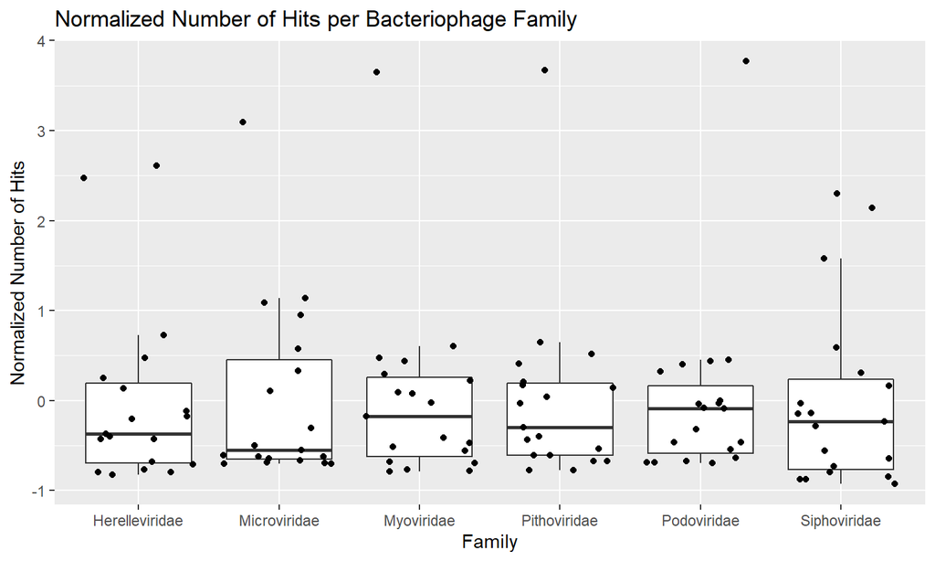

## Any Further Analysis within Tidyverse Universe Now Available

## Heatmaps

- Show visually relative strength of levels of 2 variables
- Functions in base R (`heatmap()`) and `ggplot` (`geom_tile()`)

## Opinion of R Graph Gallery

*The heatmap() function is natively provided in R. It produces high quality matrix and offers statistical tools to normalize input data, run clustering algorithm and visualize the result with dendrograms.* **It is one of the very rare cases where I prefer base R to ggplot2.**

## Advantages of Base R `heatmap()`

- Can normalize data right within the function using `scale =` argument
- Produces a dendrogram of clusters of items on both axes
- **Disadvantage**: uses a matrix that needs row names
  - Row names no longer exist with tibbles
  - We need to recreate them

## Fix Original Tibble (Rectangular Version)

- The one from Excel
- Turn tibble back into a data.frame and create row names

```
## 'data.frame':    19 obs. of  6 variables:
##  $ Herelleviridae: num  23 15 1 56 24 3 15 123 5 16 ...
##  $ Microviridae  : num  5185 419 47 9244 1034 ...
##  $ Myoviridae    : num  251 60 18 209 258 68 163 282 34 88 ...
##  $ Pithoviridae  : num  31 5 9 40 30 12 44 16 7 7 ...
##  $ Podoviridae   : num  158 91 8 98 165 28 59 147 8 15 ...
##  $ Siphoviridae  : num  358 362 55 410 1353 ...
```

## Prepare and Draw the Heatmap

- Convert the data frame to a matrix
- Normalize the data with `scale =`
  - It could be scaled based either on the rows, columns or both
  - We want the columns, which are the family variables
  - There are graphic options to control text size, colors, etc.

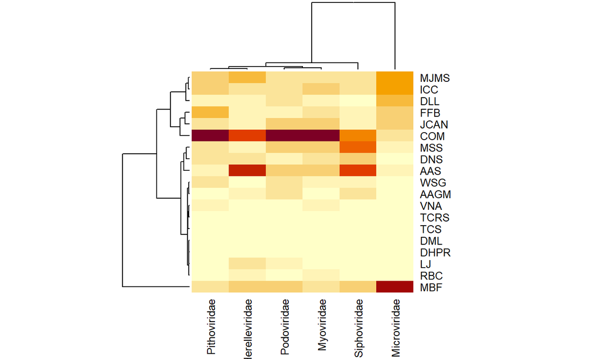

```r
heatmap1 <- heatmap(as.matrix(data_fam_mod),
                    scale = "column",
                    cexCol = 0.2 + 1/log10(19))
```